# Project 2: Tim’s stab at it

Tim Triche

November 10th, 2021

# Background

Recall that we are seeking to identify the influence of two factors on our ability to classify cells: the experimental vial and the library prep protocol. Since we are going to give in to dichotomania and label cells as “classifiable” or “not classifiable” at a given set of thresholds, we’ve got a logistic regression on our hands (i.e., we will be modeling the logit-transformed probability of classification, *p*, as the underlying response to conditions). Despite looking different from a linear model (which in the two-group case, you will recall, is tested for significance using a marginal t-test), we can rely upon a generalized version of residual variance called deviance to let us answer ANOVA-style questions: “how much variability is explained by a particular factor in the model?” First we need to set up our response variable, i.e., the ability to classify a cell confidently. For that, we need labels.

# tidySingleCellExperiment

With the release of Bioconductor 3.14, the project includes a tidy single cell experiment (data structure) package, which is great since all other single cell data structures kind of suck. (No, seriously, you’ll find out why eventually.) The package is, not coincidentally, called [tidySingleCellExperiment](http://www.bioconductor.org/packages/release/bioc/vignettes/tidySingleCellExperiment/inst/doc/introduction.html). The linked instructions are helpful; read them when you have a chance. Meanwhile, let’s make sure we can load it in this analysis.

**Make sure necessary packages are installed**

```r
if (!require("SingleCellExperiment")) {
  BiocManager::install("SingleCellExperiment")
  library(SingleCellExperiment)
}
if (!require("tidySingleCellExperiment")) {
  BiocManager::install("tidySingleCellExperiment")
  library(tidySingleCellExperiment)
}
if (!require("tidyverse")) {
  BiocManager::install("tidyverse")
  library(tidyverse)
}
```

**Load necessary packages**

```r
library(SingleCellExperiment)
library(tidySingleCellExperiment)
```

It will be challenging to draw conclusions without first loading the data.

```r
# should package this... could just instantiate from a package via data(...)
if (!exists("tidybarnyard")) {
  tidybarnyard <- readRDS(url("https://ttriche.github.io/RDS/tidybarnyard.rds"))
}
```

The *[tidySingleCellExperiment](http://www.bioconductor.org/packages/release/bioc/vignettes/tidySingleCellExperiment/inst/doc/introduction.html)* package gives us some tools to stay in the Tidyverse as much as possible while working with single-cell data. (It turns out that the underlying data makes this somewhat less trivial than you might expect. Fortunately, you don’t have to care.)

There is a [little annoyance in *tidySingleCellExperiment*](https://github.com/stemangiola/tidySingleCellExperiment/issues/38) that we need to side-step to move along. Just to be sure, let’s fix this and make sure we don’t hit it later on:

```r
# if any column in `tidybarnyard` column data is named `cell`, rename it
# this is currently a bug in tidySingleCellExperiment:
# https://github.com/stemangiola/tidySingleCellExperiment/issues/38
#
names(colData(tidybarnyard)) <- sub("cell",                       # pattern
                                    "barcode",                    # replacement
                                    names(colData(tidybarnyard))) # strings
```

# Tim’s stab at classification and plotting

It will be useful to know that, when you use the `$` operator on a typical Bioconductor object (such as a *tidySingleCellExperiment* like ours), it assumes you want to see the column data (`colData`) with that name (see below). For example, when we built up the `tidybarnyard` object from the cell and gene tables (by splitting and mutating them), we fed them to the SingleCellExperiment constructor function and it bolted them onto the side of the object. It turns out *[SingleCellExperiment](https://www.nature.com/articles/s41592-019-0654-x)* is just a modified version of *[SummarizedExperiment](https://www.nature.com/articles/nmeth.3252)*:

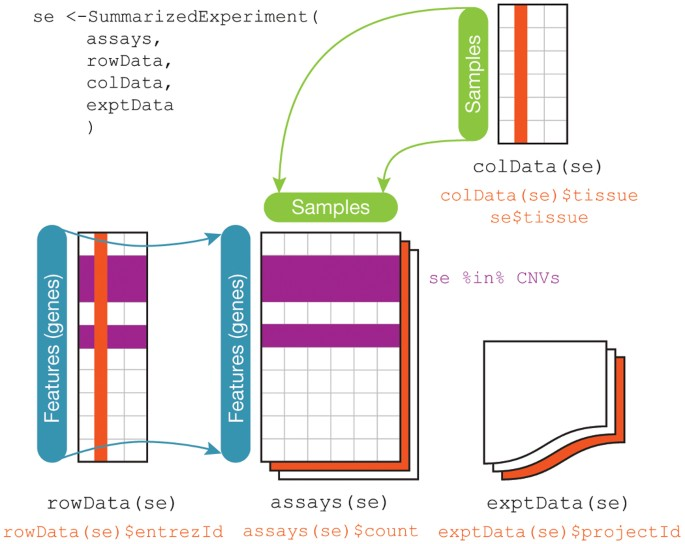

the SummarizedExperiment scheme

The figure from the original paper is better/easier to understand, although you can certainly read about the new one. TidySingleCellExperiment wraps the “newer” *[SingleCellExperiment](https://www.nature.com/articles/s41592-019-0654-x)* so that it plays somewhat more nicely with the tidyverse we’ve all been using. There are many other approaches to analyzing single-cell data, and you may well bump into several of them, but this one happens to be very efficient. Plus, keeping sample- or cell-specific details lined up with columns, and gene- or feature-specific details lined up with rows, tends to stay in style. The only annoying feature (ha!) with this setup is that you need to explicitly tell R when you want data about the rows themselves (i.e., the rowData).

Now, let’s see how these moving parts in the figure fit together, from the ground up. We will make use of the `dim` function, which provides dimensions for a rectangular object in the form rows x columns. This will also make it a little easier to keep track of what’s going on when we subset either one. To avoid the document becoming absurdly large, we’ll fold it up;

**click to open it back up.**

```r
# as what is our object masquerading?
show(tidybarnyard[,0]) # "just show me information about it, with 0 cells"
```

```
#> # A SingleCellExperiment-tibble abstraction: 0 × 5
#> [90m# Features=62046 | Assays=counts[39m
#> # … with 5 variables: cell <chr>, name <chr>, experiment <chr>, method <chr>,
#> #   barcode <chr>
```

```r
# how many rows (genes) and columns (cells) are there in our tidy barnyard?
dim(tidybarnyard)
```

```
#> [1] 62046  4199
```

```r
# is this equivalent to what we get from nrow() and ncol()?
identical(dim(tidybarnyard),
          c(nrow(tidybarnyard), ncol(tidybarnyard)))
```

```
#> [1] TRUE
```

```r
# the assay(s) should also have this many rows and columns. Do they?
identical(dim(tidybarnyard), dim(assay(tidybarnyard)))
```

```
#> [1] TRUE
```

```r
# there is a shortcut for the `counts` assay, since it's so common:
counts(tidybarnyard)[1:3, 1:3] # this holds the UMI counts, or a `.` for 0.
```

```
#> 3 x 3 sparse Matrix of class "dgCMatrix"
#>                                  Mixture1.10x-Chromium-v2.GGGCATCGTCACACGC
#> hg19_ENSG00000000003_hg19_TSPAN6                                         1
#> hg19_ENSG00000000005_hg19_TNMD                                           .
#> hg19_ENSG00000000419_hg19_DPM1                                           2
#>                                  Mixture1.10x-Chromium-v2.CACATAGAGATACACA
#> hg19_ENSG00000000003_hg19_TSPAN6                                         .
#> hg19_ENSG00000000005_hg19_TNMD                                           .
#> hg19_ENSG00000000419_hg19_DPM1                                           .
#>                                  Mixture1.10x-Chromium-v2.CACTCCATCCTCCTAG
#> hg19_ENSG00000000003_hg19_TSPAN6                                         .
#> hg19_ENSG00000000005_hg19_TNMD                                           .
#> hg19_ENSG00000000419_hg19_DPM1                                           .
```

```r
# does each row (gene) in the object have a corresponding rowData() row?
identical(rownames(tidybarnyard), rownames(rowData(tidybarnyard)))
```

```
#> [1] TRUE
```

```r
# does each column (cell) in the object have a corresponding colData() row?
identical(colnames(tidybarnyard), rownames(colData(tidybarnyard)))
```

```
#> [1] TRUE
```

```r
# is there a rowData row and a colData row that corresponds to each UMI count?
identical(dim(counts(tidybarnyard)),
          c(nrow(rowData(tidybarnyard)), nrow(colData(tidybarnyard))))
```

```
#> [1] TRUE
```

```r
# does that mean we can ask for a random cell with certain attributes?
as_tibble(tidybarnyard) %>%           # "turn the colData into a tibble"
  filter(method == "inDrops") %>%     # "choose rows where method == inDrops"
  slice_sample %>%                    # "randomly slice out one row"
  pull("cell") -> aCell               # "pull the column cell, assign to aCell"

# your cell:
show(aCell)
```

```
#> [1] "Mixture2.inDrops.TAAACCGA-AGAATGCG-TTTACCCT"
```

```r
# does that mean we can ask for a random gene with certain attributes?
as_tibble(rowData(tidybarnyard)) %>%  # "turn the rowData into a tibble"
  filter(genome == "mm10") %>%        # "choose rows where genome == mm10"
  slice_sample %>%                    # "randomly slice out one row"
  pull("name") -> aGene               # "pull the column name, assign to aGene"

# your gene:
show(aGene)
```

```
#> [1] "mm10_ENSMUSG00000079487_mm10_Med12"
```

```r
# how many copies of this random gene were found in this random cell?
counts(tidybarnyard)[aGene, aCell]    # UMI counts for a given [gene, cell].
```

```
#> [1] 1
```

```r
# note that the odds are good that you'll get a 0 for this random combination:
library(Matrix)                                 # for the `nnzero` function
sparsity <- 1 - (nnzero(counts(tidybarnyard)) / # number of nonzero counts
                 prod(dim(tidybarnyard)))       # number of rows * columns

# specifically, the chance of getting a zero is about 92.3%:
message(round(sparsity * 100, 1), "%")
```

```
#> 92.3%
```

```r
# This is fairly typical for a single-cell experiment, perhaps a bit low even.
# You could also take 10000 or so random samples to estimate the sparsity.
# For example, you could grab 100 genes from 100 cells at a time:
as_tibble(tidybarnyard) %>%       # turn tidybarnyard's colData into a tibble
  slice_sample(n=100) %>%         # slice out 100 random rows, and then...
  pull("cell") -> aHundredCells   # assign the "cell" column to "aHundredCells"

as_tibble(rowData(tidybarnyard)) %>% # turn tidybarnyard's rowData into a tibble
  slice_sample(n=100) %>%            # slice out 100 random rows, and then
  pull("name") -> aHundredGenes      # assign "name" column to "aHundredGenes"

samples <- (length(aHundredCells) * length(aHundredGenes))
nonzero <- nnzero(counts(tidybarnyard)[aHundredGenes, aHundredCells])
sparsity_hat <- (samples - nonzero) / samples
sparsity_hat # estimated sparsity
```

```
#> [1] 0.9242
```

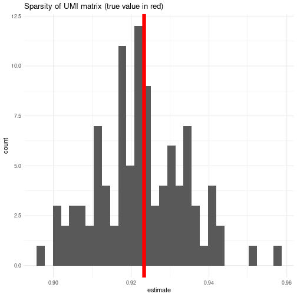

```r
# In fact, we can use this scheme to look at sampling error:
sample_sparsity <- function(object, cells=100, genes=100) {

  samples <- cells * genes
  columns <- pull(slice_sample(as_tibble(object), n=cells), "cell")
  rows <- pull(slice_sample(as_tibble(rowData(object)), n=genes), "name")
  nonzero <- nnzero(counts(object)[rows, columns])
  sparsity <- (samples - nonzero) / samples
  return(sparsity)

}

# the `replicate` function allows us to apply this many times over:
estimates <- replicate(n=100, sample_sparsity(tidybarnyard)) # "do it 100 times"

# plot estimates:
library(ggplot2)
ggplot(tibble(estimate=estimates), aes(estimate)) +
  geom_histogram() +
  geom_vline(xintercept=sparsity, color="red", lwd=3) +
  theme_minimal() +
  ggtitle("Sparsity of UMI matrix (true value in red)")
```

```r
# the Central Limit Theorem lives to fight another day,
# and we have a decent idea of how to navigate our data.
```

Often, when someone cracks open a single cell dataset, the first thing they do is to cluster the cells (based on whatever approach is fashionable). We don’t need to do that here. In fact, if you do plot the usual UMAP’ed clusters, you’ll mostly just see a batch effect. This takes a while to compute, so I recommend you not bother with the next chunk. I’ll drop in a plotly screengrab.

**Only peek if you want to see why UMAP can mislead you**

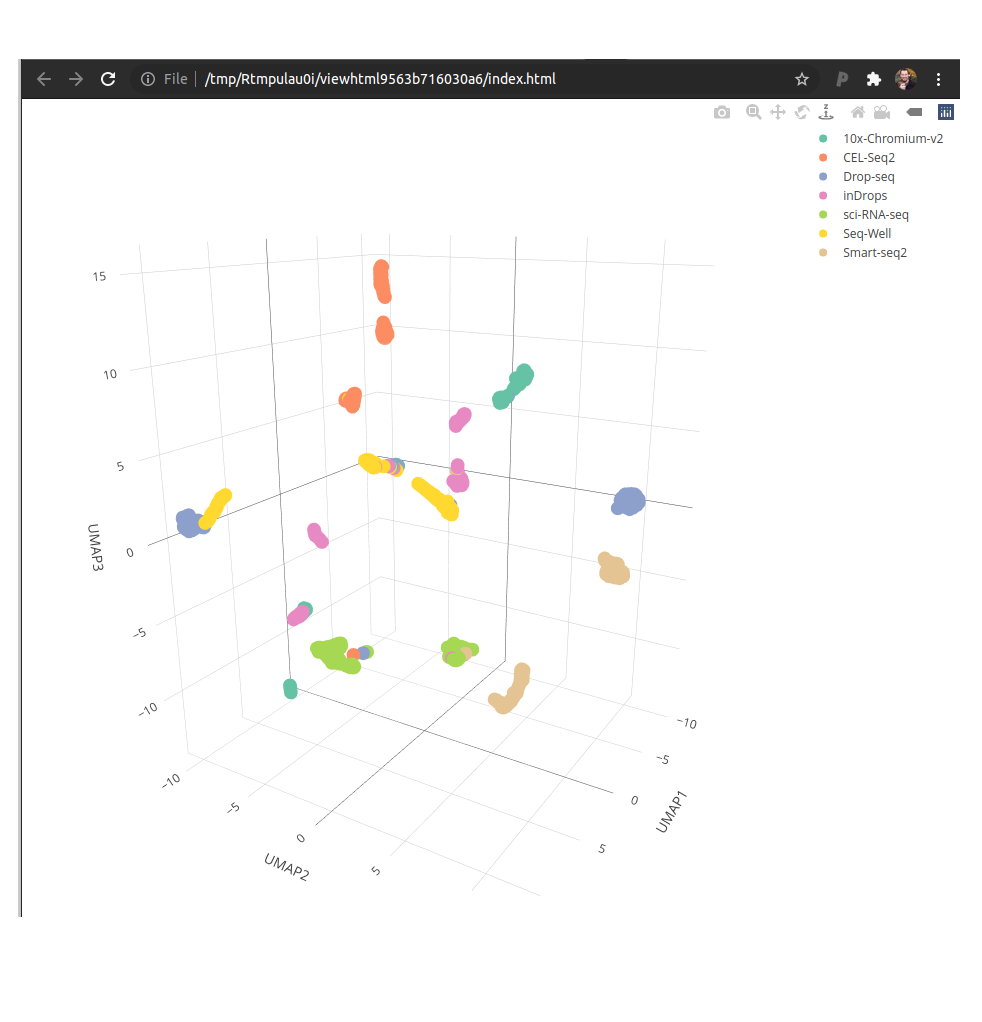

UMAP plotly

```r
library(scater)
# it is standard to log-normalize counts
# (although it's not actually a great idea)
tidybarnyard <- logNormCounts(tidybarnyard)

# compute UMAP embedding on the most variable genes
tidybarnyard %>% runUMAP(ncomponents=3) -> tidyUMAP

# plot using plotly, color by method
tidyUMAP %>%
  plot_ly(
    x =~ `UMAP1`,
    y =~ `UMAP2`,
    z =~ `UMAP3`,
    color =~ method
  )
```

For this project, we know that the reads from each library (cell) were competitively aligned against the mouse and human genomes. So all we really need to do is to decide what we’ll call a “mouse cell”, what we’ll call a “human cell”, and which we aren’t confident calling either (unclassifiable).

Originally, I wrote a little function to calculate what fraction of transcripts from a genome were present in a given cell, and then made a matrix out of the results. But since we already have a place to store the per-cell results, why not just use that instead?

```r
# identify the mouse genes:
as_tibble(rowData(tidybarnyard)) %>%  # make a tibble from the rowData
  filter(genome == "mm10") %>%        # select just the mouse mm10 genes
  pull("name") -> mouseGenes          # assign their name column to mouseGenes

# for technical reasons, it's faster to tally expressed genes this way:
tidybarnyard$fracmouse <-
  (colSums(counts(tidybarnyard)[mouseGenes, ] > 0)) / length(mouseGenes)

# do the same thing but with human genes:
as_tibble(rowData(tidybarnyard)) %>%  # make a tibble from the rowData
  filter(genome == "hg19") %>%        # select just the human hg19 genes
  pull("name") -> humanGenes          # assign their name column to humanGenes

# same remarks as previously
tidybarnyard$frachuman <-
  (colSums(counts(tidybarnyard)[humanGenes, ] > 0)) / length(humanGenes)

# why normalize by gene count?
as_tibble(rowData(tidybarnyard)) %>% select("genome") %>% table
```

```
#> .
#>  hg19  mm10
#> 33354 28692
```

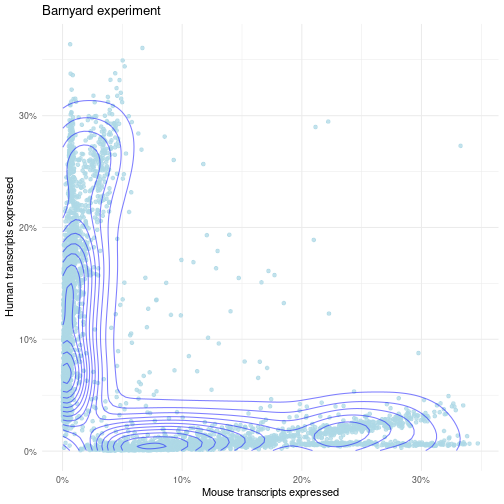

```r
# let's use ggplot to make sense of the results:
barnyardtibble <- as_tibble(tidybarnyard)

p <- ggplot(barnyardtibble, aes(x=fracmouse, y=frachuman)) +
  xlab("Mouse transcripts expressed") +
  scale_x_continuous(labels = scales::percent) +
  ylab("Human transcripts expressed") +
  scale_y_continuous(labels = scales::percent) +
  geom_point(alpha=0.75, color="lightblue") +
  geom_density2d(alpha=0.5, color="blue") +
  theme_minimal()

# first pass at a plot:
p + ggtitle("Barnyard experiment")
```

# Gating

Suppose we want to implement some logic for “gating” cells. For example, we might say “if a cell has greater than 0.05 human transcriptomes expressed, but less than 0.05 mouse transcriptomes, we’ll call it human; if vice versa, we’ll call it a mouse cell; and if it has more than 0.05 of each, it’s suspect”.

Needless to say this can stand a bit of exploration. Originally, I thought I’d need to resort to writing functions for this purpose. Now I think it’s actually better to do it in a ‘tidy’ fashion. Let’s use `mutate` for this purpose.

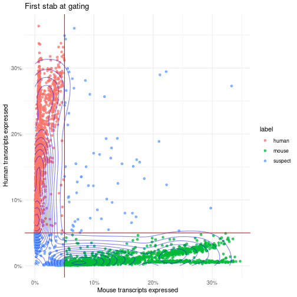

```r
# arbitrarily:
minhuman <- 0.05
minmouse <- 0.05
# Let's label any cell that is more than 5% (0.05) of BOTH genomes as suspect.

# add a label:
barnyardtibble %>%
  mutate(label =
         case_when(frachuman > minhuman & fracmouse < minmouse ~ "human",
                   fracmouse > minmouse & frachuman < minhuman ~ "mouse",
                   TRUE ~ "suspect")) -> barnyardtibble

# add our initial stab at labeling:
p <- ggplot(barnyardtibble, aes(x=fracmouse, y=frachuman, color=label)) +
  xlab("Mouse transcripts expressed") +
  scale_x_continuous(labels = scales::percent) +
  ylab("Human transcripts expressed") +
  scale_y_continuous(labels = scales::percent) +
  geom_point(alpha=0.75) +
  theme_minimal()

# plot it with some gates and density lines:
p + geom_density2d(alpha=0.5, color="blue") +
  geom_vline(xintercept=minmouse, color="red") +
  geom_hline(yintercept=minhuman, color="red") +
  ggtitle("First stab at gating")
```

This is looking a little better, but the density plots suggest there’s a “hump” at about 19% mouse or about 21% human above which the cells look like doublets.

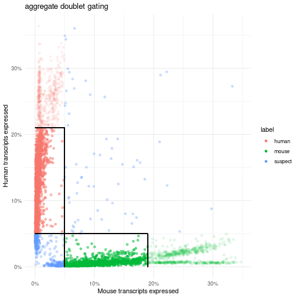

```r
# arbitrarily:
maxhuman <- 0.21
maxmouse <- 0.19

# make it obvious which cells are going to be gated out if we do this:
barnyardtibble %>%
  mutate(doublet = frachuman > maxhuman | fracmouse > maxmouse) %>%
  mutate(shading = case_when(label == "suspect" ~ 0.3,
                             doublet == TRUE ~ 0.1,
                             TRUE ~ 0.5)) -> barnyardtibble

# start like the previous plot, but add low and high "gates" for each species:
p <- ggplot(barnyardtibble,
            aes(x=fracmouse, y=frachuman, color=label, alpha=I(shading))) +
  xlab("Mouse transcripts expressed") +
  scale_x_continuous(labels = scales::percent) +
  ylab("Human transcripts expressed") +
  scale_y_continuous(labels = scales::percent) +
  geom_point() +
  geom_segment(y=0, yend=minhuman, x=minmouse, xend=minmouse, color="black") +
  geom_segment(y=0, yend=minhuman, x=maxmouse, xend=maxmouse, color="black") +
  geom_segment(y=minhuman, yend=minhuman, x=minmouse, xend=maxmouse,
               color="black") +
  geom_segment(y=minhuman, yend=minhuman, x=0, xend=minmouse, color="black") +
  geom_segment(y=maxhuman, yend=maxhuman, x=0, xend=minmouse, color="black") +
  geom_segment(y=minhuman, yend=maxhuman, x=minmouse, xend=minmouse,
               color="black") +
  theme_minimal()

# plot it
p + ggtitle("aggregate doublet gating")
```

Before we gate those out, let’s see if this is related to library prep method:

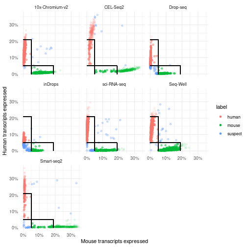

```r
# reuse the plot again:
p + facet_wrap(~ method)
```

On second thought, let’s gate on the minimums instead of throwing away cells. We know this isn’t a perfect approach to choosing a library prep method, but it’s surprisingly less bad than many approaches (“what’s fashionable?”, etc).

```r
# we need a 0/1 outcome to perform logistic regression:
barnyardtibble %>% mutate(classifiable = label != "suspect") -> barnyardtibble

# logistic regression in R uses the glm() or general linear model function,
# with a binomial (0/1) link, and the result can be compared like any lm():
fit0 <- glm(classifiable ~ 1, data=barnyardtibble, family=binomial) # null model

# add `method` to the predictors
fit1 <- update(fit0, classifiable ~ method)

# add `method` and `experiment` to the predictors
fit2 <- update(fit1, classifiable ~ method + experiment)

# add `method` and `experiment` to the predictors, no intercept
fit3 <- update(fit2, classifiable ~ method + experiment + 0)

# add `method` as the sole predictor, no intercept
fit4 <- update(fit0, classifiable ~ method + 0)
```

Remember that logistic regression transforms the input probabilities, and that means the coefficient estimates transform too. (Specifically, via `logit()`.) In order to estimate the impact of a predictor back in “normal” space, you need to expit (i.e., inverse logit) the values. Happily, the `coefplot` package will do this for you, and the results can be interpreted as “what are the odds that I will be able to classify a given cell with this method”.

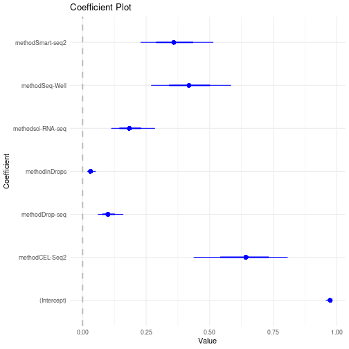

```r
# it's better to use confidence intervals than p-values for fitting purposes,
# and it's even better yet to plot them all:
library(coefplot)

# classifiable ~ method
coefplot(fit1, trans=invlogit) + theme_minimal()


```

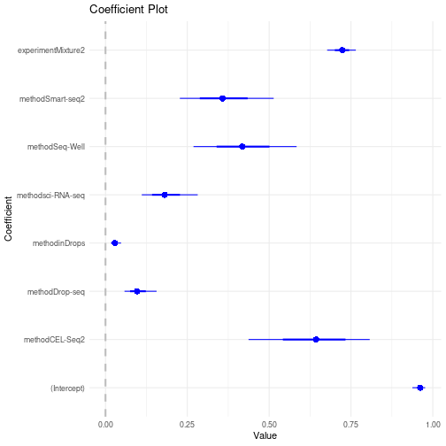

```r
# classifiable ~ method + experiment
coefplot(fit2, trans=invlogit) + theme_minimal()


```

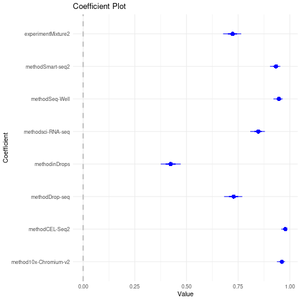

```r
# classifiable ~ method + experiment, no intercept
coefplot(fit3, trans=invlogit) + theme_minimal()


```

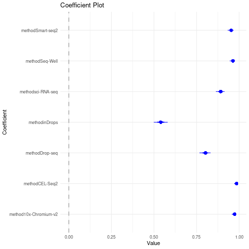

```r
# classifiable ~ method, no intercept
coefplot(fit4, trans=invlogit) + theme_minimal()


```

Any thoughts on which library prep you’d use if cost is no object?